# Week 5

```r
# Rounded percentages of variance captured by each PC, print them out
pca_pr<-round(1*s$importance[2,]*100, digits=2)
pca_pr
```

```
##   PC1   PC2   PC3   PC4   PC5   PC6   PC7   PC8
## 99.99  0.01  0.00  0.00  0.00  0.00  0.00  0.00
```

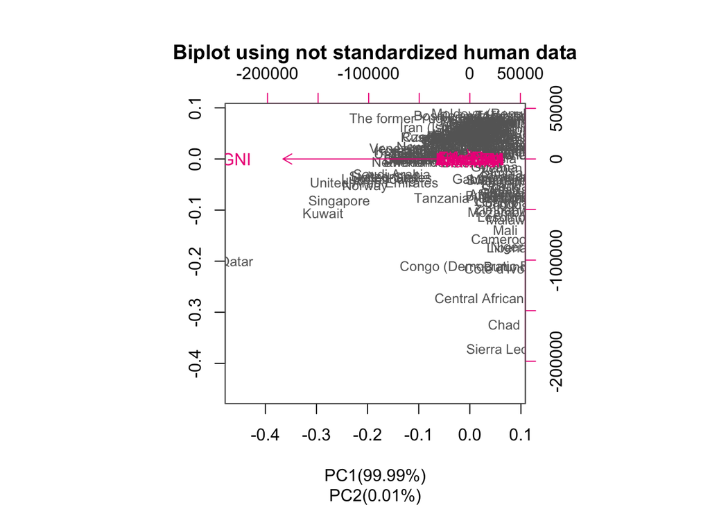

```r
# Create object pc_lab to be used as axis labels
pc_lab<-paste0(names(pca_pr), "(", pca_pr, "%)")

# Draw a biplot (and suppress warnings for zero-lenght arrows)
suppressWarnings(biplot(pca_human, cex=c(0.8,1), col=c("grey40", "deeppink2"), xlab=pc_lab, ylab=NA, main="Biplot using not standardized human data"))
```

Next the PCA is done for the standardized variables. Now we can get more principal components. Comparing not-standardized and standardized PCAs, it is clear that PCA is sensitive to the scaling of original values, assuming that features that have larger variance are more important. From this standardized biplot it is clearly visible that Labo.FM and Parli.F are their own group, as well Mat.Mor and Ado.Birth are, and all the rest 4 variables are in the grouped on the left side of this biplot. So this means that maternal mortality ratio and adolescent birth rate are somehow related onto similar features and they are quite opposite of the high life expectancy at birth, expected years of schooling for children of school entering age, gross national income per capita and the proportion of females divided with proportion of males with at least secondary education. In other words, if we think about countries, those countries are more left which have higher education (also for girls), population health, and their people have more money to use. On the right are the countries which have higher mortality ratio for mother in childbirth and under aged girls are becoming mothers. On the top there are countries with larger number proportion of females in work life or having place in the parliament, while below part of the biplot there are less females than males in the parliament and work.

```r
# Perform principal component analysis on the standardized human data (with the SVD method)
pca_human_scaled<-prcomp(human_scaled)

# Create and print summary of pca_human
s_s<-summary(pca_human_scaled)
s_s
```

```
## Importance of components:
##                           PC1    PC2     PC3     PC4     PC5     PC6
## Standard deviation     2.0708 1.1397 0.87505 0.77886 0.66196 0.53631
## Proportion of Variance 0.5361 0.1624 0.09571 0.07583 0.05477 0.03595
## Cumulative Proportion  0.5361 0.6984 0.79413 0.86996 0.92473 0.96069
##                            PC7     PC8
## Standard deviation     0.45900 0.32224
## Proportion of Variance 0.02634 0.01298
## Cumulative Proportion  0.98702 1.00000
```

```r
# Rounded percentages of variance captured by each PC, print them out
pca_pr2<-round(1*s_s$importance[2,]*100, digits=1)
pca_pr2
```

```
##  PC1  PC2  PC3  PC4  PC5  PC6  PC7  PC8
## 53.6 16.2  9.6  7.6  5.5  3.6  2.6  1.3
```

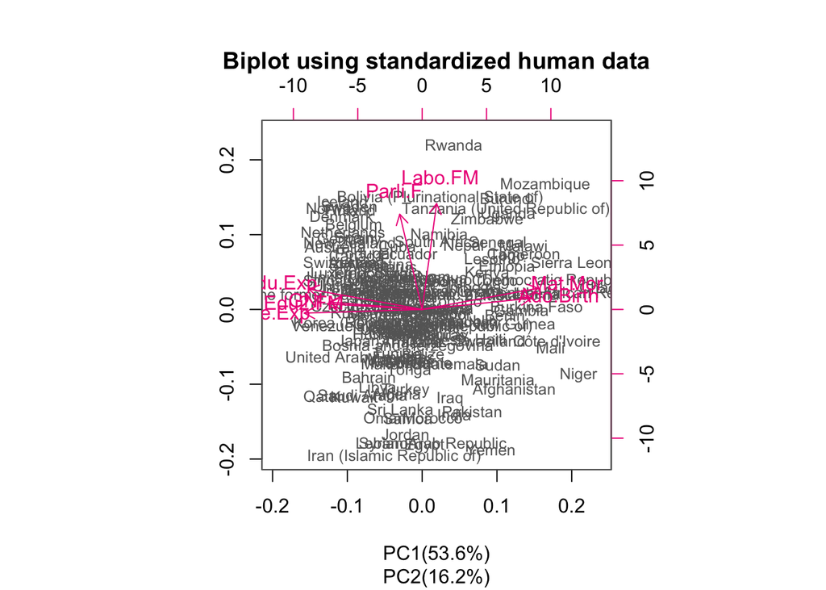

```r
# Create object pc_lab to be used as axis labels
pc_lab<-paste0(names(pca_pr2), "(", pca_pr2, "%)")

# Draw a biplot for standardized data
biplot(pca_human_scaled, cex=c(0.8,1), col=c("grey40", "deeppink2"), xlab=pc_lab, ylab=NA, main="Biplot using standardized human data")
```

```r
# Access to FactoMineR (includes tea data) and dplyr (suppress warnings)
suppressPackageStartupMessages({
library("dplyr")
})
library(FactoMineR)
library(dplyr)

# The names of the datasets in the FactoMineR
data(package="FactoMineR")

# Load tea dataset from the package
data(tea)

# Summary and structure (questions) of the tea dataset
summary(tea)
```

```
##          breakfast           tea.time          evening          lunch
##  breakfast    :144   Not.tea time:131   evening    :103   lunch    : 44
##  Not.breakfast:156   tea time    :169   Not.evening:197   Not.lunch:256
##
##
##
##
##
##         dinner           always          home           work
##  dinner    : 21   always    :103   home    :291   Not.work:213
##  Not.dinner:279   Not.always:197   Not.home:  9   work    : 87
##
##
##
##
##
##         tearoom           friends          resto          pub
##  Not.tearoom:242   friends    :196   Not.resto:221   Not.pub:237
##  tearoom    : 58   Not.friends:104   resto    : 79   pub    : 63
##
##
##
##
##
##         Tea         How           sugar                     how
##  black    : 74   alone:195   No.sugar:155   tea bag           :170
##  Earl Grey:193   lemon: 33   sugar   :145   tea bag+unpackaged: 94
##  green    : 33   milk : 63                  unpackaged        : 36
##                  other:  9
##
##
##
##                   where                 price          age        sex
##  chain store         :192   p_branded      : 95   Min.   :15.00   F:178
##  chain store+tea shop: 78   p_cheap        :  7   1st Qu.:23.00   M:122
##  tea shop            : 30   p_private label: 21   Median :32.00
##                             p_unknown      : 12   Mean   :37.05
##                             p_upscale      : 53   3rd Qu.:48.00
##                             p_variable     :112   Max.   :90.00
##
```

[output cut: 25 more lines]

```
##  feminine    :129   Not.sophisticated: 85   No.slimming:255
##  Not.feminine:171   sophisticated    :215   slimming   : 45
##
##
##
##
##
##         exciting          relaxing              effect.on.health
##  exciting   :116   No.relaxing:113   effect on health   : 66
##  No.exciting:184   relaxing   :187   No.effect on health:234
##
##
##
##
##
```

```r
str(tea)
```

```
## 'data.frame':    300 obs. of  36 variables:
##  $ breakfast       : Factor w/ 2 levels "breakfast","Not.breakfast": 1 1 2 2 1 2 1 2 1 1 ...
##  $ tea.time        : Factor w/ 2 levels "Not.tea time",..: 1 1 2 1 1 1 2 2 2 1 ...
##  $ evening         : Factor w/ 2 levels "evening","Not.evening": 2 2 1 2 1 2 2 1 2 1 ...
##  $ lunch           : Factor w/ 2 levels "lunch","Not.lunch": 2 2 2 2 2 2 2 2 2 2 ...
##  $ dinner          : Factor w/ 2 levels "dinner","Not.dinner": 2 2 1 1 2 1 2 2 2 2 ...
##  $ always          : Factor w/ 2 levels "always","Not.always": 2 2 2 2 1 2 2 2 2 2 ...
##  $ home            : Factor w/ 2 levels "home","Not.home": 1 1 1 1 1 1 1 1 1 1 ...
##  $ work            : Factor w/ 2 levels "Not.work","work": 1 1 2 1 1 1 1 1 1 1 ...
##  $ tearoom         : Factor w/ 2 levels "Not.tearoom",..: 1 1 1 1 1 1 1 1 1 2 ...
##  $ friends         : Factor w/ 2 levels "friends","Not.friends": 2 2 1 2 2 2 1 2 2 2 ...
##  $ resto           : Factor w/ 2 levels "Not.resto","resto": 1 1 2 1 1 1 1 1 1 1 ...
##  $ pub             : Factor w/ 2 levels "Not.pub","pub": 1 1 1 1 1 1 1 1 1 1 ...
##  $ Tea             : Factor w/ 3 levels "black","Earl Grey",..: 1 1 2 2 2 2 2 1 2 1 ...
##  $ How             : Factor w/ 4 levels "alone","lemon",..: 1 3 1 1 1 1 1 3 3 1 ...
```

[output cut: 22 more lines]

In above there is a structure of tea data. It has the 300 objects and 36 variables as it should have. The questions are the columns in the data set and they are factors with 2 or more levels meaning that the individuals need to choose the answer from given 2 or more options. Only difference is the age, where the answer needs to be integer.

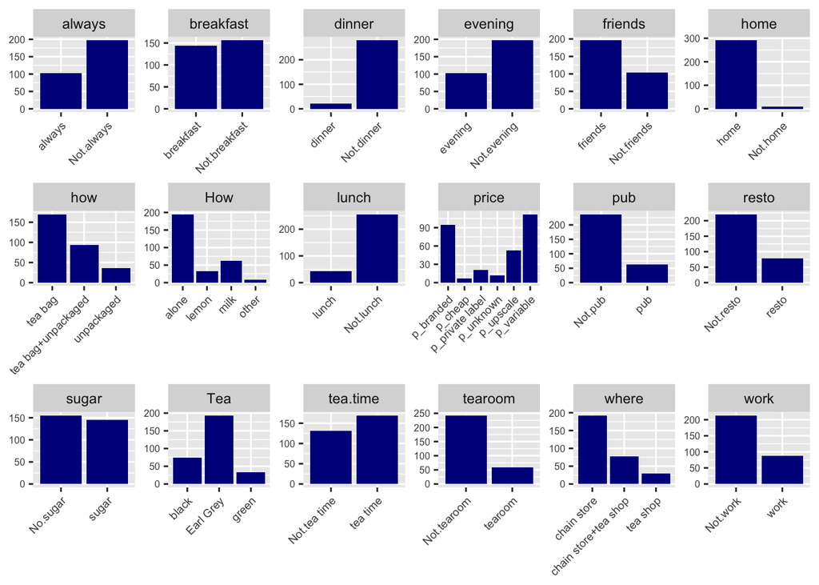

```r
# Dividing data for groups for analysis (tea_how, personal information, perception)
keep_columns1<-c("breakfast", "tea.time", "evening", "lunch","dinner","always","home","work","tearoom","friends","resto","pub","Tea","How","sugar","how","where","price")
keep_columns2<-c("age","sex", "SPC","Sport","age_Q","frequency")
keep_columns3<-c("escape.exoticism", "spirituality", "healthy", "diuretic", "friendliness", "iron.absorption", "feminine", "sophisticated", "slimming", "exciting", "relaxing")

tea_how<-dplyr::select(tea, one_of(keep_columns1))
tea_inf<-dplyr::select(tea, one_of(keep_columns2))
tea_per<-dplyr::select(tea, one_of(keep_columns3))

# visualize the how dataset (and suppress some warnings)
suppressWarnings(gather(tea_how)%>%ggplot(aes(value))+facet_wrap("key", nrow=3, scales="free")+geom_bar(fill="darkblue")+theme(axis.text.x=element_text(angle=45, hjust=1, size=7), axis.text.y=element_text(hjust=1, size=6), axis.title.x = element_blank(), axis.title.y=element_blank()))
```

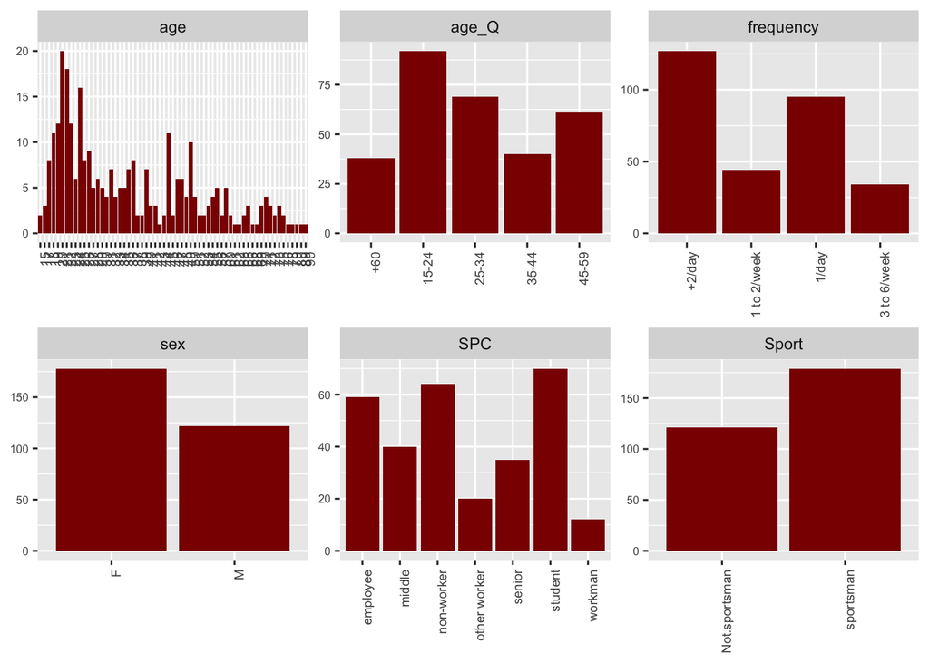

```r
suppressWarnings(gather(tea_inf)%>%ggplot(aes(value))+facet_wrap("key", scales="free")+geom_bar(fill="darkred")+theme(axis.text.x=element_text(angle=90, hjust=1, size=7), axis.text.y=element_text(hjust=1, size=6), axis.title.x = element_blank(), axis.title.y=element_blank()))
```

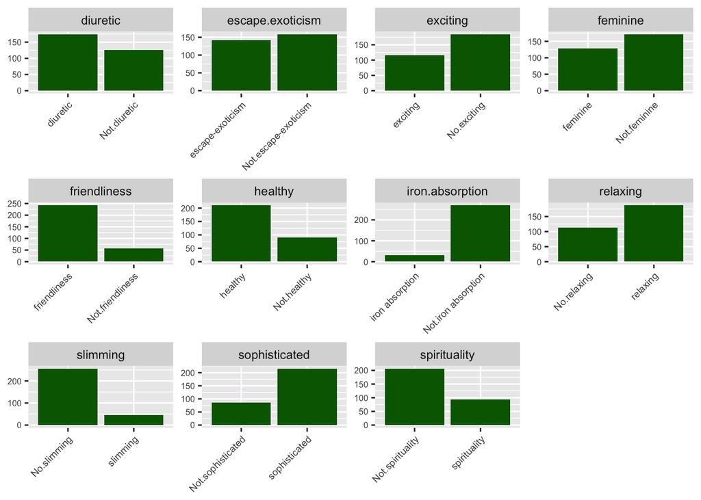

```r
suppressWarnings(gather(tea_per)%>%ggplot(aes(value))+facet_wrap("key", scales="free")+geom_bar(fill="darkgreen")+theme(axis.text.x=element_text(angle=45, hjust=1, size=7), axis.text.y=element_text(hjust=1, size=6), axis.title.x = element_blank(), axis.title.y=element_blank()))
```

Then do Multiple Correspondence Analysis on the tea data (or to a certain columns of the data, it’s up to you). Interpret the results of the MCA and draw at least the variable biplot of the analysis. You can also explore other plotting options for MCA. Comment on the output of the plots.

```r
# MCA for tea_how, having
mca_tea<-MCA(tea, quanti.sup=19, quali.sup=20:36, graph=F)

# Summary for the models
summary(mca_tea)
```

```
##
## Call:
## MCA(X = tea, quanti.sup = 19, quali.sup = 20:36, graph = F)
##
##
## Eigenvalues
##                        Dim.1   Dim.2   Dim.3   Dim.4   Dim.5   Dim.6
## Variance               0.148   0.122   0.090   0.078   0.074   0.071
## % of var.              9.885   8.103   6.001   5.204   4.917   4.759
## Cumulative % of var.   9.885  17.988  23.989  29.192  34.109  38.868
##                        Dim.7   Dim.8   Dim.9  Dim.10  Dim.11  Dim.12
## Variance               0.068   0.065   0.062   0.059   0.057   0.054
## % of var.              4.522   4.355   4.123   3.902   3.805   3.628
## Cumulative % of var.  43.390  47.745  51.867  55.769  59.574  63.202
##                       Dim.13  Dim.14  Dim.15  Dim.16  Dim.17  Dim.18
## Variance               0.052   0.049   0.048   0.047   0.046   0.040
## % of var.              3.462   3.250   3.221   3.127   3.037   2.683
## Cumulative % of var.  66.664  69.914  73.135  76.262  79.298  81.982
##                       Dim.19  Dim.20  Dim.21  Dim.22  Dim.23  Dim.24
## Variance               0.038   0.037   0.036   0.035   0.031   0.029
## % of var.              2.541   2.438   2.378   2.323   2.055   1.915
## Cumulative % of var.  84.523  86.961  89.339  91.662  93.717  95.633
##                       Dim.25  Dim.26  Dim.27
## Variance               0.027   0.021   0.017
## % of var.              1.821   1.407   1.139
## Cumulative % of var.  97.454  98.861 100.000
##
## Individuals (the 10 first)
##                  Dim.1    ctr   cos2    Dim.2    ctr   cos2    Dim.3
## 1             | -0.541  0.658  0.143 | -0.149  0.061  0.011 | -0.306
## 2             | -0.361  0.293  0.133 | -0.078  0.017  0.006 | -0.633
## 3             |  0.073  0.012  0.003 | -0.169  0.079  0.018 |  0.246
## 4             | -0.572  0.735  0.235 |  0.018  0.001  0.000 |  0.203
## 5             | -0.253  0.144  0.079 | -0.118  0.038  0.017 |  0.006
## 6             | -0.684  1.053  0.231 |  0.032  0.003  0.001 | -0.018
## 7             | -0.111  0.027  0.022 | -0.182  0.090  0.059 | -0.207
## 8             | -0.210  0.099  0.043 | -0.068  0.013  0.004 | -0.421
## 9             |  0.118  0.031  0.012 |  0.229  0.144  0.044 | -0.538
## 10            |  0.258  0.150  0.045 |  0.478  0.627  0.156 | -0.482
##                  ctr   cos2
```

[output cut: 73 more lines]

```
##                    Dim.1 Dim.2 Dim.3
## sex              | 0.033 0.017 0.003 |
## SPC              | 0.032 0.053 0.076 |
## Sport            | 0.001 0.000 0.002 |
## age_Q            | 0.008 0.077 0.146 |
## frequency        | 0.094 0.006 0.064 |
## escape.exoticism | 0.000 0.007 0.000 |
## spirituality     | 0.005 0.000 0.016 |
## healthy          | 0.000 0.000 0.008 |
## diuretic         | 0.004 0.000 0.013 |
## friendliness     | 0.071 0.001 0.013 |
##
## Supplementary continuous variable
##                  Dim.1    Dim.2    Dim.3
## age           |  0.042 |  0.204 | -0.340 |
```

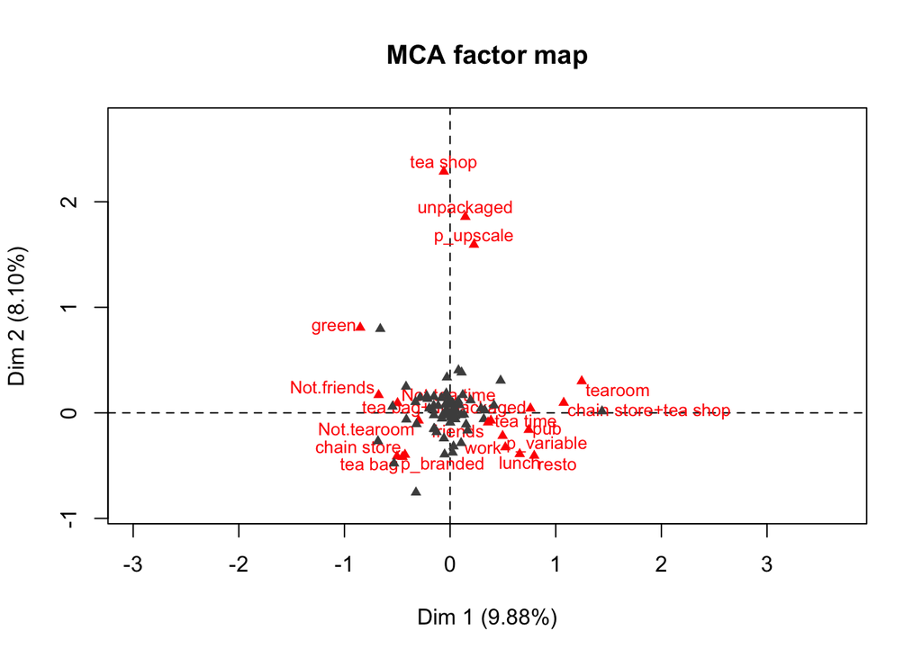

```r
# Visualize mca_tea
plot(mca_tea, invisible=c("ind"), cex=0.8, selectMod="contrib 20", unselect="grey30")
```

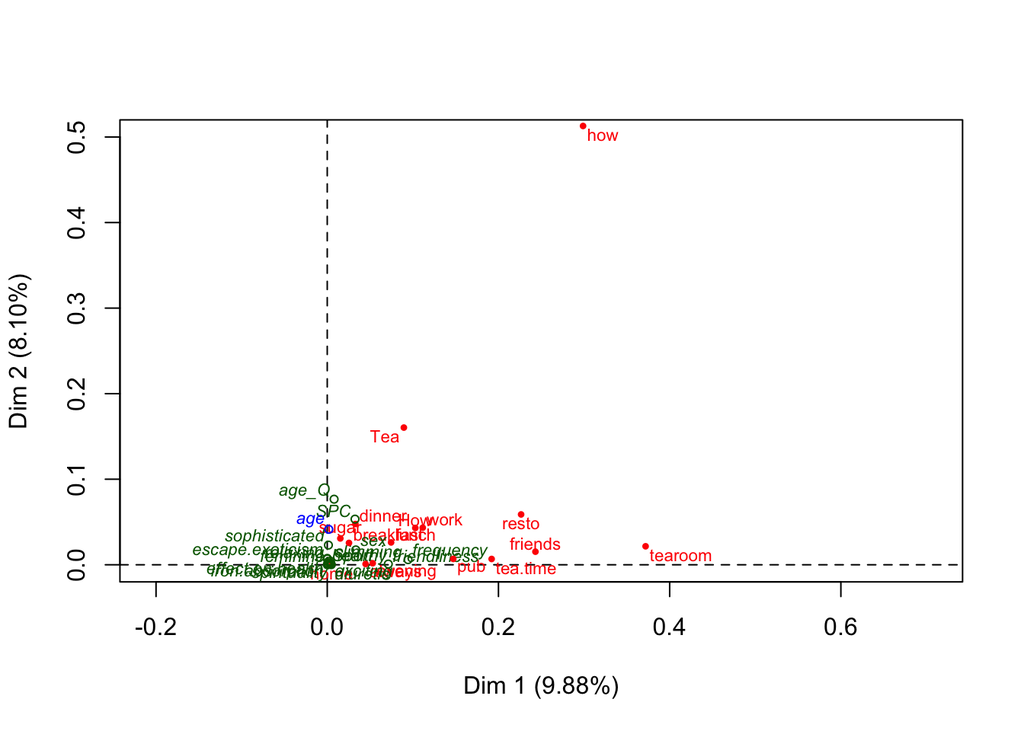

```r
# Another visualization of the mca_tea
plot(mca_tea, choix="var", xlim=c(0,0.5), ylim=c(0,0.5), cex=0.7)
```

From the summary table one can read that the dimension 1 is explaining approximately 10% of the variance and the second dimension around 8%. Categorical variables are the squared correlation between each variable and dimension. If the value is close to 1, then there is a strong link between the current dimension and variable. From the summary table, the strongest link is between tearoom and dimension 1 (from 10 most correlated categorical variables). This is best visualized in the second biplot, where tearoom stands on the far right on the x-axis.

In the first MCA biplot there is no group of individuals, only variables. In the x-axis, there is dimension 1, and Y-axis is dimension 2. The 20 most contributed variables are written in red color, other variables are just grey triangles in the MCA biplot.

The second biplot is coloring the variables so in red you can see the active variables, in green the supplementary categorical variables and in blue the supplementary continuous variables. The coordinate for a categorical variable on a dimension is squared correlation ratio between the dimension and the categorical variable, where as the coordinate for a continuous variable on a dimension is a squared correlation coefficient between the dimension and the continuous variable. The distance between variable categories gives a measure in their similarity, so in the last plot it is seen that resto and friends are closer than Tea and friends.